# Motivation to participate on the Crowdsourced Reform of Finland’s Condominium-Law

Analysis on the motivations for taking part of the crowdsourced process of reforming the condominium-law of Finland.

### Before Starting Survey

Main Question: Why do you want to participate in the crowdsourcing process organized by the Ministry of Justice? Please rate the following statements on scale: Strongly disagree (1) - Strongly agree (7).

1. I want to solve problems in homeowners’ associations.
2. I want to improve the condominium law.
3. I’m unhappy with my own homeowner’s association.
4. I want to learn more about the condominium law.
5. I participate because I want to pass time.
6. I’m curious.
7. I want to discuss the topic with others.

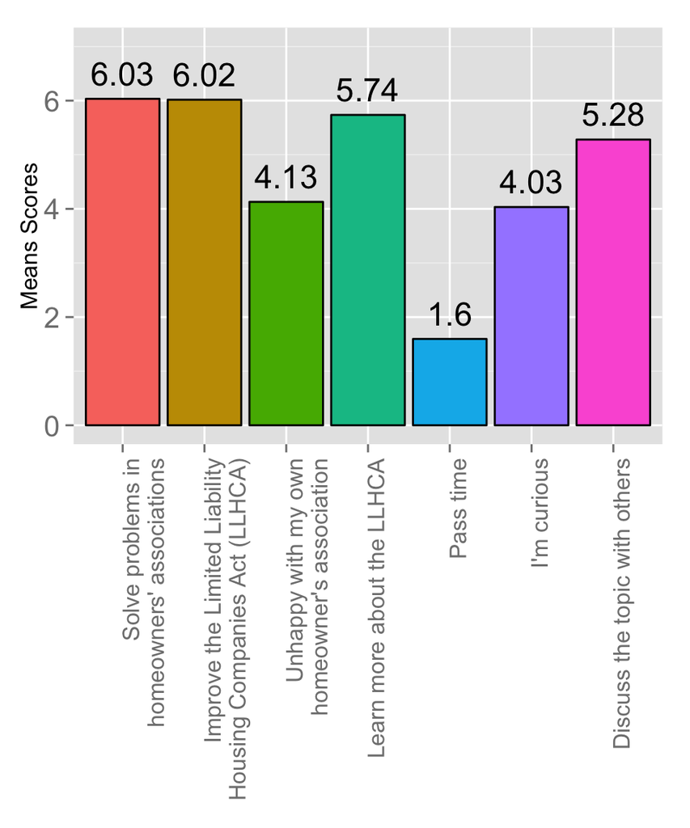

Before starting two factors appeared to be somehow equally important for the participants as the strongest motivation to take part on the initiative. With pretty high mean scores, the willingness in solving homeowners’association problems **(mean of 6.03)** and the desire to improve the condominium law **(mean of 6.02)** showed to be most the important motivation factors.

To a lesser extent, the interest of learning aspects of the condominium law and the motivation of performing a social activity, like discussing the topic with others, do not appear to be as relevant as the previous mentioned considering the statistically significant difference between their mean scores, **5.74 (p-value 0.05)** and **5.28 (p-value 0.18e-5)** respectively, and the highest mean score.

From the remaining factors, the unhappiness with the personal homeowners association and curiosity seem not to be important, even when received mean scores above half of the maximum scale (7). Definitively, participants do not show up just to pass time.

### After the Experience Survey

Main Question: Why did you participate in the crowdsourcing process organized by the Ministry of Justice? Please rate the following statements on scale (1) Strongly disagree - (7) Strongly agree.

1. I wanted to solve problems in homeowners’ associations.
2. I wanted to improve the condominium law.
3. I’m unhappy with my own homeowner’s association.
4. I wanted to learn more about the condominium law.
5. I participated to pass time.
6. I’m curious.
7. I wanted to discuss the topic with others.
8. I was interested in the other participants’ views.

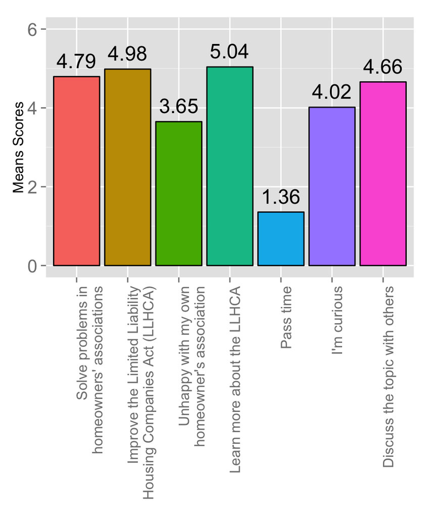

At the end of the experience, the motivation factors showed interesting changes. Learning about the law still appears to be one of the most important factors. Even when the learning factor’s mean score has slightly deceased (from **5.74** to **5.04**), its reduction does not appear to be significant.

On their own, improving the condominium law and solving conflicts in homeowners’s associations factors showed to be relevant yet, considering that their mean scores still appear among the highest ones. However, they seem to be less important than before starting the process taking into consideration the significant decrease in their means scores, which passed from **6.02** to **4.98 (p-value 0.28e-06)** and from **6.03** to **4.79 (p-value 0.22e-04)**, respectively.

Discussing the condominium law with others is another factor that has became less important, noticing by the significant decrease **(p-value 0.005)** of its mean score, which passed from **5.28** to **4.66**.

It seems that after the experience the disappointment with the homeowners’ association accounted less when deciding to participate or not in the reform of the condominium law, although, the reduction in the mean score of this factor does not appear to be significant **(p-value 0.071)**.

The low importance of curiosity and leisure as motivation factors, it seems to be confirmed by the similar and small means scores, **4.02** and **1.36** respectively, received again.

#### The main motivation factor

A posteriori, the main factor, that seems to drove participants’ decision to take part in the process, is the interest of getting to know other’s point of view regarding the condominium law. With a interestingly high mean score of **5.2**, this factor has been pointed, in the last survey, as the biggest reason that triggered participation. Without being included in the pre-experience survey, it turns out that after taken part of the process participants had gotten enriched so much from each other’s point of views that assessed this factor as the main cause that drove their decisions to participate.

### Comparison

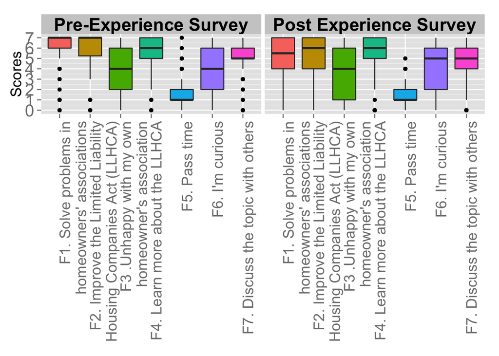